# 00_of_text_classification_dlam

```python
## METHODOLGY
```

### APPROACH

This notebook trains a malware analysis model to classify binary files as *malicious* or *benign*, based on the extracted assembly of the executable. This model is *binary*—or two-class—classification, an important and widely applicable kind of machine learning problem.

### USED MODULES

```python
import matplotlib.pyplot as plt
import os
import re
import shutil
import string
import tensorflow as tf

from tensorflow.keras import layers
from tensorflow.keras import losses
from tensorflow.keras import preprocessing
from tensorflow.keras.layers.experimental.preprocessing import TextVectorization
from tensorflow.keras import callbacks
from datetime import *

import sys
# Add the workspace folder path to the sys.path list
sys.path.append('/Users/macbookpro/Documents/Workspace/binary_classification_reverse/model')
from reverse.data import plot_accuracy, plot_confusion_matrix
```

```python
print(tf.__version__)
```

```
2.5.0
```

```python
max_features = 1000
sequence_length = 1024
batch_size = 16
seed = 42
embedding_dim = 256
epochs = 15
max_length = 100000
ngrams = 3
```

```python
print("embedding_dim  : " ,embedding_dim)
print("batch_size      : ",batch_size)
print("seed            : " ,seed )
print("max_features    : " , max_features )
print("ngrams          : ", ngrams)
print("sequence_length : " , sequence_length)
print("epochs          : ", epochs)
```

```
embedding_dim  :  256
batch_size      :  16
seed            :  42
max_features    :  1000
ngrams          :  3
sequence_length :  1024
epochs          :  15
```

### Tensorboard

We are using Tensorboard to view accuracy and histogram values we will use the callback while fitting the model.

```python
logdir = "./logs/scalars/" + datetime.now().strftime("%Y%m%d-%H%M%S")
tensorboard_callback = callbacks.TensorBoard(log_dir=logdir,
 histogram_freq=0,  # How often to log histogram visualizations
    embeddings_freq=0,  # How often to log embedding visualizations
    update_freq="epoch"
)
```

### sorel-20m dataset

```python
dataset_dir = os.path.join(os.path.dirname("./"), 'dataset')
```

```python
os.listdir(dataset_dir)
```

```
['.DS_Store', 'test', 'train']
```

```python
train_dir = os.path.join(dataset_dir, 'train')
os.listdir(train_dir)
```

```
['bngn', '.DS_Store', 'malw']
```

```python
# sample_file = os.path.join(train_dir, 'bngn/sn.exe.txt')
# with open(sample_file) as f:
#   print(f.read())
```

### Load the dataset

Next, I will load the data off disk and prepare it into a format suitable for training. To do so, I will use the helpful text_dataset_from_directory utility, which expects a directory structure as follows.

```
main_directory/
...bngn/
......exeutable_1.exe..txt
......exeutable_2.exe.txt
...malw/
......hash_value1.txt
......hash_value2.txt
```

To prepare a dataset for binary classification, we will need two folders on disk, corresponding to `bngn` and `malw`. These will be the malicious and benign binary executables, which can be found in `dataset/train/bngn` and `dataset/train/malw`.

```python
try:
    remove_dir = os.path.join(train_dir, '.DS_Store')
    shutil.rmtree(remove_dir)
except Exception as e:
    pass
```

Next, I will use the `text_dataset_from_directory` utility to create a labeled `tf.data.Dataset`. [tf.data](https://www.tensorflow.org/guide/data) is a powerful collection of tools for working with data.

When running a machine learning experiment, it is a best practice to divide the dataset into three splits: [train](https://developers.google.com/machine-learning/glossary#training_set), [validation](https://developers.google.com/machine-learning/glossary#validation_set), and [test](https://developers.google.com/machine-learning/glossary#test-set).

My dataset has already been divided into train and test, but it lacks a validation set. Let's create a validation set using an 80:20 split of the training data by using the `validation_split` argument below.

```python
raw_train_ds = tf.keras.preprocessing.text_dataset_from_directory(
    './dataset/train/',
    batch_size=batch_size,
    validation_split=0.2,
    max_length=max_length,
    subset='training',
    seed=seed)
```

```
Found 1309 files belonging to 2 classes.
Using 1048 files for training.
```

As we can see above, there are 1,309 examples in the training folder, of which we will use 80% (or 1048) for training. Now we can also iterate over the dataset and print out a few examples as follows.

```python
# for text_batch, label_batch in raw_train_ds.take(1):
#   for i in range(1):
#     print("Assembly Code", text_batch.numpy()[i])
#     print("Label", label_batch.numpy()[i])
```

The labels are 0 or 1. To see which of these correspond to malicious and benign executables, we can check the `class_names` property on the dataset.

```python
print("Label 0 corresponds to", raw_train_ds.class_names[0])
print("Label 1 corresponds to", raw_train_ds.class_names[1])
```

```
Label 0 corresponds to bngn
Label 1 corresponds to malw
```

Note: When using the `validation_split` and `subset` arguments, we are specifying a random seed, (or to pass `shuffle=False`,) so that the validation and training splits have no overlap.

```python
raw_val_ds = tf.keras.preprocessing.text_dataset_from_directory(
    './dataset/train',
    batch_size=batch_size,
    validation_split=0.2,
    max_length=max_length,
    subset='validation',
    seed=seed)
```

```
Found 1309 files belonging to 2 classes.
Using 261 files for validation.
```

```python
raw_test_ds = tf.keras.preprocessing.text_dataset_from_directory(
    './dataset/test',
    max_length=max_length,
    batch_size=batch_size)
```

```
Found 182 files belonging to 2 classes.
```

Note: The Preprocessing APIs used in the following section are experimental in TensorFlow 2.3 and subject to change.

### Prepare the dataset for training

Next, I will standardize, tokenize, and vectorize the data using the helpful `preprocessing.TextVectorization` layer.

Standardization refers to preprocessing the assembly, typically to remove punctuation or HTML elements to simplify the dataset. Tokenization refers to splitting strings into tokens (for example, splitting an instruction into individual words, by splitting on whitespace). Vectorization refers to converting tokens into numbers so they can be fed into a neural network. All of these tasks can be accomplished with this layer.

Note: to prevent [train/test skew](https://developers.google.com/machine-learning/guides/rules-of-ml#training-serving_skew) (also know as train/serving skew), it is important to preprocess the data identically at train and test time. To facilitate this, the `TextVectorization` layer can be included directly inside our model, as shown later in this model.

```python
def custom_standardization(input_data):
  lowercase = tf.strings.lower(input_data)
  stripped_asm = tf.strings.regex_replace(lowercase, '<.*?>', ' ')
  stripped_asm = tf.strings.regex_replace(stripped_asm, '\n', ' ')
  stripped_asm = tf.strings.regex_replace(stripped_asm, '(bad)', ' ')
  stripped_asm = tf.strings.regex_replace(stripped_asm, 'align', ' ')
  stripped_asm = tf.strings.regex_replace(stripped_asm, 'int3', ' ')
  stripped_asm = tf.strings.regex_replace(stripped_asm, 'r"\([^()]*\)",', ' ')
  stripped_asm = tf.strings.regex_replace(stripped_asm, r'(0x[0-9a-fA-F]+)(?:)?', 'addr')
  stripped_asm = tf.strings.regex_replace(stripped_asm, 'r"([d|q]{0,}word |byte )"', "dqw")
  stripped_asm = tf.strings.regex_replace(stripped_asm, '[a-z]+mov|mov[a-z]*', 'mov')
  stripped_asm = tf.strings.regex_replace(stripped_asm, '[a-z]+mov|mov[a-z]*', 'mov')
  return tf.strings.regex_replace(stripped_asm,
                                  '[%s]' % re.escape(string.punctuation),
                                  ' ')
```

Next, I will create a `TextVectorization` layer. I will use this layer to standardize, tokenize, and vectorize our data. I set the `output_mode` to `int` to create unique integer indices for each token.

Note that we're using the default split function, and the custom standardization function we defined above. We'll also define some constants for the model, like an explicit maximum `sequence_length`, which will cause the layer to pad or truncate sequences to exactly `sequence_length` values.

```python
vectorize_layer = TextVectorization(
    standardize=custom_standardization,
    max_tokens=max_features,
    output_mode='int',
    ngrams=ngrams,
    output_sequence_length=sequence_length)
```

Next, I will call `adapt` to fit the state of the preprocessing layer to the dataset. This will cause the model to build an index of opcodes and operands to integers.

Note: it's important to only use our training data when calling adapt (using the test set would leak information).

```python
# Make a text-only dataset (without labels), then call adapt
train_text = raw_train_ds.map(lambda x, y: x)
vectorize_layer.adapt(train_text)
```

Let's create a function to see the result of using this layer to preprocess some data.

```python
def vectorize_text(text, label):
  text = tf.expand_dims(text, -1)
  return vectorize_layer(text), label
```

```python
# retrieve a batch (of 32 assembly texts and labels) from the dataset
text_batch, label_batch = next(iter(raw_train_ds))
first_asm, first_label = text_batch[0], label_batch[0]
print("Asm", first_asm.numpy()[:250])
print("Label", raw_train_ds.class_names[first_label])
print("Vectorized opcode sequence", vectorize_text(first_asm, first_label))
```

```
Asm b'dec ebp.pop edx.nop.add BYTE PTR [ebx],al.add BYTE PTR [eax],al.add BYTE PTR [eax+eax*1],al.add BYTE PTR [eax],al.(bad).inc DWORD PTR [eax].add BYTE PTR [eax+0x0],bh.add BYTE PTR [eax],al.add BYTE PTR [eax+0x0],al.add BYTE PTR [eax],al.fadd DWORD PTR'
Label malw
Vectorized opcode sequence (<tf.Tensor: shape=(1, 1024), dtype=int64, numpy=array([[101,  17,  37, ...,  85,  71,  74]])>, <tf.Tensor: shape=(), dtype=int32, numpy=1>)
```

As we can see above, each token has been replaced by an integer. We can lookup the token (string) that each integer corresponds to by calling `.get_vocabulary()` on the layer.

```python
for i in range(2,25):
    print("{} ---> {}".format(str(i),vectorize_layer.get_vocabulary()[i]))
print('Vocabulary size: {}'.format(len(vectorize_layer.get_vocabulary())))
```

```
2 ---> addr
3 ---> ptr
4 ---> eax
5 ---> byte
6 ---> byte ptr
7 ---> dword
8 ---> dword ptr
9 ---> add
10 ---> mov
11 ---> al
12 ---> ptr eax
13 ---> add byte
14 ---> add byte ptr
15 ---> push
16 ---> esi
17 ---> ebp
18 ---> ecx
19 ---> byte ptr eax
20 ---> edi
21 ---> addr mov
22 ---> ebx
23 ---> edx
24 ---> ebp addr
Vocabulary size: 1000
```

We are ready to train our model. As a final preprocessing step, we will apply the TextVectorization layer we created earlier to the train, validation, and test dataset.

```python
train_ds = raw_train_ds.map(vectorize_text)
val_ds = raw_val_ds.map(vectorize_text)
test_ds = raw_test_ds.map(vectorize_text)
```

### Configure the dataset for performance

These are two important methods we should use when loading data to make sure that I/O does not become blocking.

`.cache()` keeps data in memory after it's loaded off disk. This will ensure the dataset does not become a bottleneck while training your model. If your dataset is too large to fit into memory, you can also use this method to create a performant on-disk cache, which is more efficient to read than many small files.

`.prefetch()` overlaps data preprocessing and model execution while training.

We can learn more about both methods, as well as how to cache data to disk in the [data performance guide](https://www.tensorflow.org/guide/data_performance).

```python
AUTOTUNE = tf.data.experimental.AUTOTUNE

train_ds = train_ds.cache().prefetch(buffer_size=AUTOTUNE)
val_ds = val_ds.cache().prefetch(buffer_size=AUTOTUNE)
test_ds = test_ds.cache().prefetch(buffer_size=AUTOTUNE)
```

### Create the model

It's time to create our neural network:

```python
# model = tf.keras.Sequential([
#   # layers.Embedding(max_features + 1, embedding_dim),
#   layers.Embedding(max_features + 1, embedding_dim),
#   layers.Bidirectional(layers.LSTM(128,dropout = 0.2, recurrent_dropout = 0.5, return_sequences=True)),
#   layers.Dropout(0.2),
#   layers.Bidirectional(layers.LSTM(64,dropout = 0.2, recurrent_dropout= 0.5, return_sequences=True)),
#   layers.Dropout(0.2),
#   layers.GlobalMaxPooling1D(),
#   layers.Dropout(0.2),
#   layers.Dense(128),
#   layers.Dropout(0.2),
#   layers.Dense(1)])

# model.summary()

model = tf.keras.Sequential([
  # layers.Embedding(max_features + 1, embedding_dim),
  layers.Embedding(max_features + 1, embedding_dim),
  layers.Bidirectional(layers.LSTM(128,dropout = 0.2, recurrent_dropout = 0.5, return_sequences=True)),
  layers.Bidirectional(layers.LSTM(64,dropout = 0.2, recurrent_dropout= 0.5, return_sequences=True)),
  # layers.Dropout(0.2),
  layers.GlobalMaxPooling1D(),
  layers.Dropout(0.2),
  layers.Dense(128),
  layers.Dropout(0.2),
  layers.Dense(1)])

model.summary()
```

```
Model: "sequential"
_________________________________________________________________
Layer (type)                 Output Shape              Param #
=================================================================
embedding (Embedding)        (None, None, 256)         256256
_________________________________________________________________
bidirectional (Bidirectional (None, None, 256)         394240
_________________________________________________________________
bidirectional_1 (Bidirection (None, None, 128)         164352
_________________________________________________________________
global_max_pooling1d (Global (None, 128)               0
_________________________________________________________________
dropout (Dropout)            (None, 128)               0
_________________________________________________________________
dense (Dense)                (None, 128)               16512
_________________________________________________________________
dropout_1 (Dropout)          (None, 128)               0
_________________________________________________________________
dense_1 (Dense)              (None, 1)                 129
=================================================================
Total params: 831,489
Trainable params: 831,489
Non-trainable params: 0
_________________________________________________________________
```

### Loss function and optimizer

```python
model.compile(loss=losses.BinaryCrossentropy(from_logits=True),
              optimizer='adam',
              metrics=tf.metrics.BinaryAccuracy(threshold=0.0))
```

### Train the model

We will train the model by passing the `dataset` object to the fit method.

```python
history = model.fit(
    train_ds,
    validation_data=val_ds,
    epochs=epochs,
    callbacks=[tensorboard_callback],)
```

### Evaluate the model

Let's see how the model performs. Two values will be returned. Loss (a number which represents our error, lower values are better), and accuracy.

```python
loss, accuracy = model.evaluate(test_ds)

print("Loss: ", loss)
print("Accuracy: ", accuracy)
```

```
Loss:  0.01248365268111229
Accuracy:  0.9945054650306702
```

### Create a plot of accuracy and loss over time

There are four entries: one for each monitored metric during training and validation. We can use these to plot the training and validation loss for comparison, as well as the training and validation accuracy:

[output not shown]

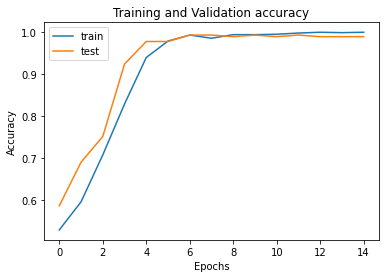

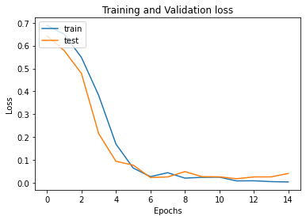

```python
from reverse.data import plot_accuracy
plot_accuracy(history)
```

For this particular case, we could prevent overfitting by simply stopping the training when the validation accuracy is no longer increasing. One way to do so is to use the [EarlyStopping callback](https://www.tensorflow.org/api_docs/python/tf/keras/callbacks/EarlyStopping?version=nightly).

## Export the model

In the code above, we applied the `TextVectorization` layer to the dataset before feeding text to the model. If we want to make our model capable of processing raw strings (for example, to simplify deploying it), we can include the `TextVectorization` layer inside our model. To do so, we can create a new model using the weights we just trained.

```python
export_model = tf.keras.Sequential([
  vectorize_layer,
  model,
  layers.Activation('sigmoid')
])

export_model.compile(
    loss=losses.BinaryCrossentropy(from_logits=False), optimizer="adam", metrics=['accuracy']
)

# Test it with `raw_test_ds`, which yields raw strings
loss, accuracy = export_model.evaluate(raw_test_ds)
print(accuracy)
```

```
0.9945054650306702
```

### Confusion Matrix

```python
from sklearn.metrics import classification_report, confusion_matrix
import numpy as np
import pandas as pd
import seaborn as sns
y_pred = []  # store predicted labels
y_true = []  # store true labels

# iterate over the dataset
for asm_batch, label_batch in raw_test_ds:   # use dataset.unbatch() with repeat
   y_true.append(label_batch)
   preds = (export_model.predict(asm_batch) > 0.5).astype("int32")
   y_pred.append(preds)

# convert the true and predicted labels into tensors
correct_labels = tf.concat([item for item in y_true], axis = 0)
predicted_labels = tf.concat([item for item in y_pred], axis = 0)

print('Confusion Matrix')
cm = confusion_matrix(y_true=correct_labels, y_pred= predicted_labels )
print(cm)
print('Classification Report')
target_names = ['Benign', 'Malware']
print(classification_report(predicted_labels, correct_labels, target_names=target_names))
```

```
Confusion Matrix
[[92  0]
 [ 1 89]]
Classification Report
              precision    recall  f1-score   support

      Benign       1.00      0.99      0.99        93
     Malware       0.99      1.00      0.99        89

    accuracy                           0.99       182
   macro avg       0.99      0.99      0.99       182
weighted avg       0.99      0.99      0.99       182
```

```
Confusion matrix, without normalization
[[92  0]
 [ 1 89]]
```

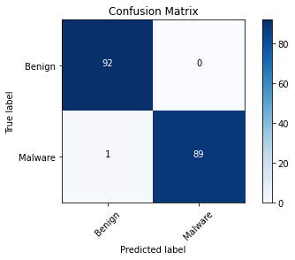

```python
from reverse.data import plot_confusion_matrix
plot_confusion_matrix(cm=cm, classes=target_names, normalize=False, title='Confusion Matrix')
```

Including the text preprocessing logic inside our model enables us to export a model for production that simplifies deployment, and reduces the potential for [train/test skew](https://developers.google.com/machine-learning/guides/rules-of-ml#training-serving_skew).

There is a performance difference to keep in mind when choosing where to apply our TextVectorization layer. Using it outside of our model enables us to do asynchronous CPU processing and buffering of our data when training on GPU. So, if we're training our model on the GPU, we will go with this option to get the best performance while developing our model, then switch to including the TextVectorization layer inside our model when we're ready to prepare for deployment.[saving and loading model](https://www.tensorflow.org/tutorials/keras/save_and_load).